# Ejercicio de feedback - Programación y entorno de trabajo para la IA

Autor/a

Juan Manuel

Fecha de publicación

13 de enero de 2026

### Carga y Limpieza de Datos

A continuación, se cargaron los conjuntos de datos y se juntaron en un solo dataframe a partir de la variable común “código”.

```r
# Cargo librerías necesarias
library(pacman)

p_load(
  tidyverse, # Easily Install and Load the 'Tidyverse'
  tidymodels, # Easily Install and Load the 'Tidymodels' Packages
  modeldata, # Data Sets Useful for Modeling Examples
  skimr, # Compact and Flexible Summaries of Data
  readxl,
  janitor, # Simple Tools for Examining and Cleaning Dirty Data
)

# Carga de datos
path <- "datos entregable.xlsx"
df_demo <- read_xlsx(path = path, sheet = "demográficos")
df_bio <- read_xlsx(path = path, sheet = "biomarcadores")
```

### Limpieza de los encabezados y eliminación de registros incompletos

Se limpiaron los nombres de los encabezados para que sea más facil trabajar con ellos, además, se eliminaron los registros de aquellas mujeres que no tuvieran información de laboratorio.

```r
# Limpio antes de unir porque "codigo" en una hoja empieza con mayúscula y
# en otra con minúscula. Así ya hago join directamente y no usando una lista
df_demo <- df_demo %>%
  clean_names()
df_bio <- df_bio %>%
  clean_names()

# Unión por ID (En este caso "codigo")
df <- inner_join(df_demo, df_bio, by = "codigo")

# Elimino los registros de aquellas mujeres que no tengan información de laboratorio
# Para ello cojo todas las columnas del subconjunto bio menos codigo
cols_bio <- df_bio %>%
  colnames() %>%
  .[!. %in% c("codigo")]

# Uso dropNA de tidyr
df <- df %>%
    # Elimino la fila completa si encuentro un NA de alguna de las columnas
    drop_na(all_of(cols_bio))

# Hago un descriptivo básico usando skimr
skimr::skim(df)
```

Data summary

| Name | df |
| --- | --- |
| Number of rows | 797 |
| Number of columns | 33 |
| _______________________ |  |
| Column type frequency: |  |
| character | 5 |
| numeric | 27 |
| POSIXct | 1 |
| ________________________ |  |
| Group variables | None |

**Variable type: character**

| skim_variable | n_missing | complete_rate | min | max | empty | n_unique | whitespace |
| --- | --- | --- | --- | --- | --- | --- | --- |
| area_de_salud | 0 | 1.00 | 5 | 7 | 0 | 8 | 0 |
| hospital | 0 | 1.00 | 6 | 13 | 0 | 8 | 0 |
| lactancia_materna | 0 | 1.00 | 2 | 2 | 0 | 2 | 0 |
| otro_tipo_de_lactancia | 0 | 1.00 | 2 | 2 | 0 | 2 | 0 |
| ocupacion_habitual_pareja | 11 | 0.99 | 3 | 101 | 0 | 536 | 0 |

**Variable type: numeric**

| skim_variable | n_missing | complete_rate | mean | sd | p0 | p25 | p50 | p75 | p100 | hist |
| --- | --- | --- | --- | --- | --- | --- | --- | --- | --- | --- |
| codigo | 0 | 1.00 | 409.85 | 239.46 | 1.00 | 203.00 | 407.00 | 616.00 | 829.00 | ▇▇▇▇▇ |
| peso_de_la_madre | 0 | 1.00 | 83.69 | 15.04 | 46.40 | 73.00 | 82.50 | 92.70 | 151.30 | ▂▇▅▁▁ |
| responde | 0 | 1.00 | 1.00 | 0.00 | 1.00 | 1.00 | 1.00 | 1.00 | 1.00 | ▁▁▇▁▁ |
| edad_de_la_madre | 0 | 1.00 | 30.39 | 5.15 | 15.00 | 27.00 | 31.00 | 34.00 | 46.00 | ▁▃▇▅▁ |
| peso_al_nacimiento | 0 | 1.00 | 3335.18 | 488.62 | 1170.00 | 3040.00 | 3350.00 | 3680.00 | 4900.00 | ▁▂▇▇▁ |
| tiempo_de_embarazo_al_parto | 0 | 1.00 | 279.45 | 4.66 | 266.00 | 276.00 | 279.00 | 282.00 | 294.00 | ▁▅▇▅▁ |
| lactancia_en_embarazo_anterior | 367 | 0.54 | 0.64 | 0.48 | 0.00 | 0.00 | 1.00 | 1.00 | 1.00 | ▅▁▁▁▇ |
| gine_publico | 0 | 1.00 | 0.93 | 0.26 | 0.00 | 1.00 | 1.00 | 1.00 | 1.00 | ▁▁▁▁▇ |
| gine_privado | 0 | 1.00 | 0.11 | 0.31 | 0.00 | 0.00 | 0.00 | 0.00 | 1.00 | ▇▁▁▁▁ |
| clases_de_parto | 0 | 1.00 | 0.66 | 0.47 | 0.00 | 0.00 | 1.00 | 1.00 | 1.00 | ▅▁▁▁▇ |
| numero_de_clases_de_parto | 271 | 0.66 | 8.73 | 6.07 | 1.00 | 4.00 | 8.00 | 12.00 | 36.00 | ▇▂▁▁▁ |
| cesarea | 0 | 1.00 | 0.21 | 0.41 | 0.00 | 0.00 | 0.00 | 0.00 | 1.00 | ▇▁▁▁▂ |
| biberon | 0 | 1.00 | 0.78 | 1.08 | 0.00 | 0.00 | 1.00 | 1.00 | 5.00 | ▇▁▁▁▁ |
| numero_de_hijos | 0 | 1.00 | 1.45 | 0.68 | 1.00 | 1.00 | 1.00 | 2.00 | 8.00 | ▇▁▁▁▁ |
| nacional | 0 | 1.00 | 1.06 | 0.24 | 1.00 | 1.00 | 1.00 | 1.00 | 3.00 | ▇▁▁▁▁ |
| profesion | 0 | 1.00 | 2.22 | 0.76 | 1.00 | 2.00 | 2.00 | 2.00 | 4.00 | ▁▇▁▁▁ |
| nivel_de_estudios | 0 | 1.00 | 4.08 | 1.05 | 1.00 | 4.00 | 4.00 | 5.00 | 6.00 | ▁▁▇▂▁ |
| pareja | 0 | 1.00 | 0.99 | 0.11 | 0.00 | 1.00 | 1.00 | 1.00 | 1.00 | ▁▁▁▁▇ |
| situacion_laboral_pareja | 9 | 0.99 | 1.14 | 0.58 | 1.00 | 1.00 | 1.00 | 1.00 | 5.00 | ▇▁▁▁▁ |
| tension_arterial_media | 0 | 1.00 | 109.46 | 9.78 | 83.00 | 102.00 | 108.00 | 115.00 | 150.00 | ▁▇▆▁▁ |
| glucosa | 0 | 1.00 | 95.52 | 14.15 | 60.35 | 86.26 | 95.17 | 104.44 | 141.99 | ▂▇▇▃▁ |
| hdl | 0 | 1.00 | 55.93 | 12.31 | 25.66 | 47.12 | 56.05 | 64.28 | 93.83 | ▂▆▇▃▁ |
| ldl | 0 | 1.00 | 337.35 | 6089.90 | 54.84 | 103.58 | 120.63 | 137.98 | 172045.00 | ▇▁▁▁▁ |
| trigliceridos | 0 | 1.00 | 126.64 | 68.91 | 0.00 | 78.38 | 110.79 | 155.64 | 564.44 | ▇▆▁▁▁ |
| creatinina | 0 | 1.00 | 0.91 | 0.20 | 0.41 | 0.77 | 0.92 | 1.05 | 1.60 | ▂▆▇▂▁ |
| hemoglobina | 0 | 1.00 | 13.62 | 2.33 | 10.09 | 12.70 | 13.59 | 14.36 | 70.25 | ▇▁▁▁▁ |
| colesterol_total | 0 | 1.00 | 418.61 | 6089.59 | 117.20 | 181.61 | 202.38 | 221.95 | 172116.84 | ▇▁▁▁▁ |

**Variable type: POSIXct**

| skim_variable | n_missing | complete_rate | min | max | median | n_unique |
| --- | --- | --- | --- | --- | --- | --- |
| fecha_de_nacimiento | 0 | 1 | 1980-01-15 12:00:00 | 2010-12-30 06:00:00 | 1995-11-03 06:00:00 | 797 |

```r
# Analizando brevemente con skim se observaron valores anómalos que pueden tratarse
# de erratas. Estas variables son ldl, colesterol_total y hemoglobina, que tienen
# valores atípicos extremadamente altos.

# Cambio estos valores a NA
df <- df %>%
  mutate(
    ldl = ifelse(ldl > 300, NA, ldl),
    colesterol_total = ifelse(colesterol_total > 400, NA, colesterol_total),
    hemoglobina = ifelse(hemoglobina > 20, NA, hemoglobina)
  )
```

### Análisis descriptivo y recodificación de variables categóricas

Con el fin de identificar valores extraños para pasarlos a NA, se realizó un análisis descriptivo básico de todas las variables a través de la función `skim()` del paquete `skimr`. Posteriormente, se recodificaron las variables categóricas para que tuvieran las etiquetas de datos apropiadas según el diccionario de datos proporcionado.

```r
# Compruebo que se cambiaron correctamente
df %>%
    select(ldl, colesterol_total, hemoglobina) %>%
    skimr::skim()
```

Data summary

| Name | Piped data |
| --- | --- |
| Number of rows | 797 |
| Number of columns | 3 |
| _______________________ |  |
| Column type frequency: |  |
| numeric | 3 |
| ________________________ |  |
| Group variables | None |

**Variable type: numeric**

| skim_variable | n_missing | complete_rate | mean | sd | p0 | p25 | p50 | p75 | p100 | hist |
| --- | --- | --- | --- | --- | --- | --- | --- | --- | --- | --- |
| ldl | 1 | 1 | 121.63 | 27.52 | 54.84 | 103.56 | 120.58 | 137.94 | 240.89 | ▂▇▅▁▁ |
| colesterol_total | 1 | 1 | 202.91 | 32.69 | 117.20 | 181.60 | 202.32 | 221.91 | 320.51 | ▁▇▇▂▁ |
| hemoglobina | 1 | 1 | 13.55 | 1.19 | 10.09 | 12.69 | 13.59 | 14.35 | 17.44 | ▁▅▇▃▁ |

```r
# Recodifico las variables categóricas para que tengan las etiquetas de datos apropiadas
# según el diccionario de datos
df_recodificado <- df %>%
  mutate(
    # Variables binarias numéricas (0=No, 1=Sí)
    across(
      c(gine_publico, gine_privado, cesarea, biberon, pareja, responde,
        lactancia_en_embarazo_anterior, clases_de_parto),
      ~ factor(.x, levels = c(0, 1), labels = c("No", "Sí"))
    ),

    # Variables de Texto Si/No, las paso a factor para limpiar niveles
    across(
      c(lactancia_materna, otro_tipo_de_lactancia),
      ~ factor(.x, levels = c("No", "Si", "Sí"))
    ),

    lactancia_materna = fct_recode(lactancia_materna, "Sí" = "Si"),
    otro_tipo_de_lactancia = fct_recode(otro_tipo_de_lactancia, "Sí" = "Si"),

    # Variables categóricas nominales (Multiclase)
    nacional = factor(nacional,
                      levels = c(1, 2, 3),
                      labels = c("Española", "Extranjera", "Otras/No consta")),

    profesion = factor(profesion,
                       levels = c(1, 2, 3, 4, 5),
                       labels = c("Enfermera", "Oficina", "Médico", "Profesora", "Otros")),

    situacion_laboral_pareja = factor(situacion_laboral_pareja,
                                      levels = c(1, 2, 3, 4, 5),
                                      labels = c("Activa", "Parada", "Baja", "Jubilado", "Estudiante")),

    # Variable Ordinal
    nivel_de_estudios = factor(nivel_de_estudios,
                               levels = c(1, 2, 3, 4, 5, 6),
                               labels = c("Primaria", "Secundaria", "Bachiller",
                                          "Grado", "Máster", "Doctorado"),
                               ordered = TRUE)
  )
```

### Creación de nuevas variables

Una vez los datos están limpios, el hospital solicita una variable adicional que calcule el colesterol total a partir de los valores de LDL, HDL y triglicéridos, así como una variable que indique el tipo de ginecólogo al que acudió la paciente (público, privado, ambos o ninguno).

```r
df_var <- df_recodificado %>%
  mutate(
    # Variable colesterol total para el descriptivo, calculado mediante la siguiente formula:
    # Colesterol Total = Colesterol LDL + Colesterol HDL + (Triglicéridos / 5)
    colesterol_calculado = ldl + hdl + (trigliceridos / 5),

    # Variable tipo de ginecologo
    tipo_ginecologo = case_when(
      gine_publico == "Sí" & gine_privado == "No" ~ "Público",
      gine_publico == "No" & gine_privado == "Sí" ~ "Privado",
      gine_publico == "Sí" & gine_privado == "Sí" ~ "Ambos",
      TRUE ~ "Ninguno"
    )
  )
```

### Análisis descriptivo y visualizaciones

Para obtener una visión general de las variables en el conjunto de datos limpio, se realizó un análisis descriptivo utilizando la función `skim()`. Además, se crearon visualizaciones para explorar la distribución de los parámetros de laboratorio y la relación entre diferentes variables.

```r
df_var %>%
  # Seleccionamos variables de interés (quitamos IDs, fechas, textos libres)
  select(-codigo, -fecha_de_nacimiento, -ocupacion_habitual_pareja, -colesterol_calculado) %>%
  skim()
```

Data summary

| Name | Piped data |
| --- | --- |
| Number of rows | 797 |
| Number of columns | 31 |
| _______________________ |  |
| Column type frequency: |  |
| character | 3 |
| factor | 14 |
| numeric | 14 |
| ________________________ |  |
| Group variables | None |

**Variable type: character**

| skim_variable | n_missing | complete_rate | min | max | empty | n_unique | whitespace |
| --- | --- | --- | --- | --- | --- | --- | --- |
| area_de_salud | 0 | 1 | 5 | 7 | 0 | 8 | 0 |
| hospital | 0 | 1 | 6 | 13 | 0 | 8 | 0 |
| tipo_ginecologo | 0 | 1 | 5 | 7 | 0 | 3 | 0 |

**Variable type: factor**

| skim_variable | n_missing | complete_rate | ordered | n_unique | top_counts |
| --- | --- | --- | --- | --- | --- |
| responde | 0 | 1.00 | FALSE | 1 | Sí: 797, No: 0 |
| lactancia_materna | 0 | 1.00 | FALSE | 2 | No: 431, Sí: 366 |
| otro_tipo_de_lactancia | 0 | 1.00 | FALSE | 2 | Sí: 572, No: 225 |
| lactancia_en_embarazo_anterior | 367 | 0.54 | FALSE | 2 | Sí: 275, No: 155 |
| gine_publico | 0 | 1.00 | FALSE | 2 | Sí: 741, No: 56 |
| gine_privado | 0 | 1.00 | FALSE | 2 | No: 712, Sí: 85 |
| clases_de_parto | 0 | 1.00 | FALSE | 2 | Sí: 525, No: 272 |
| cesarea | 0 | 1.00 | FALSE | 2 | No: 630, Sí: 167 |
| biberon | 40 | 0.95 | FALSE | 2 | Sí: 425, No: 332 |
| nacional | 0 | 1.00 | FALSE | 3 | Esp: 754, Ext: 41, Otr: 2 |
| profesion | 0 | 1.00 | FALSE | 4 | Ofi: 546, Méd: 88, Pro: 84, Enf: 79 |
| nivel_de_estudios | 0 | 1.00 | TRUE | 6 | Gra: 447, Más: 143, Bac: 72, Doc: 71 |
| pareja | 0 | 1.00 | FALSE | 2 | Sí: 788, No: 9 |
| situacion_laboral_pareja | 9 | 0.99 | FALSE | 5 | Act: 725, Par: 40, Jub: 10, Est: 8 |

**Variable type: numeric**

| skim_variable | n_missing | complete_rate | mean | sd | p0 | p25 | p50 | p75 | p100 | hist |
| --- | --- | --- | --- | --- | --- | --- | --- | --- | --- | --- |
| peso_de_la_madre | 0 | 1.00 | 83.69 | 15.04 | 46.40 | 73.00 | 82.50 | 92.70 | 151.30 | ▂▇▅▁▁ |
| edad_de_la_madre | 0 | 1.00 | 30.39 | 5.15 | 15.00 | 27.00 | 31.00 | 34.00 | 46.00 | ▁▃▇▅▁ |
| peso_al_nacimiento | 0 | 1.00 | 3335.18 | 488.62 | 1170.00 | 3040.00 | 3350.00 | 3680.00 | 4900.00 | ▁▂▇▇▁ |
| tiempo_de_embarazo_al_parto | 0 | 1.00 | 279.45 | 4.66 | 266.00 | 276.00 | 279.00 | 282.00 | 294.00 | ▁▅▇▅▁ |
| numero_de_clases_de_parto | 271 | 0.66 | 8.73 | 6.07 | 1.00 | 4.00 | 8.00 | 12.00 | 36.00 | ▇▂▁▁▁ |
| numero_de_hijos | 0 | 1.00 | 1.45 | 0.68 | 1.00 | 1.00 | 1.00 | 2.00 | 8.00 | ▇▁▁▁▁ |
| tension_arterial_media | 0 | 1.00 | 109.46 | 9.78 | 83.00 | 102.00 | 108.00 | 115.00 | 150.00 | ▁▇▆▁▁ |
| glucosa | 0 | 1.00 | 95.52 | 14.15 | 60.35 | 86.26 | 95.17 | 104.44 | 141.99 | ▂▇▇▃▁ |
| hdl | 0 | 1.00 | 55.93 | 12.31 | 25.66 | 47.12 | 56.05 | 64.28 | 93.83 | ▂▆▇▃▁ |
| ldl | 1 | 1.00 | 121.63 | 27.52 | 54.84 | 103.56 | 120.58 | 137.94 | 240.89 | ▂▇▅▁▁ |
| trigliceridos | 0 | 1.00 | 126.64 | 68.91 | 0.00 | 78.38 | 110.79 | 155.64 | 564.44 | ▇▆▁▁▁ |
| creatinina | 0 | 1.00 | 0.91 | 0.20 | 0.41 | 0.77 | 0.92 | 1.05 | 1.60 | ▂▆▇▂▁ |
| hemoglobina | 1 | 1.00 | 13.55 | 1.19 | 10.09 | 12.69 | 13.59 | 14.35 | 17.44 | ▁▅▇▃▁ |
| colesterol_total | 1 | 1.00 | 202.91 | 32.69 | 117.20 | 181.60 | 202.32 | 221.91 | 320.51 | ▁▇▇▂▁ |

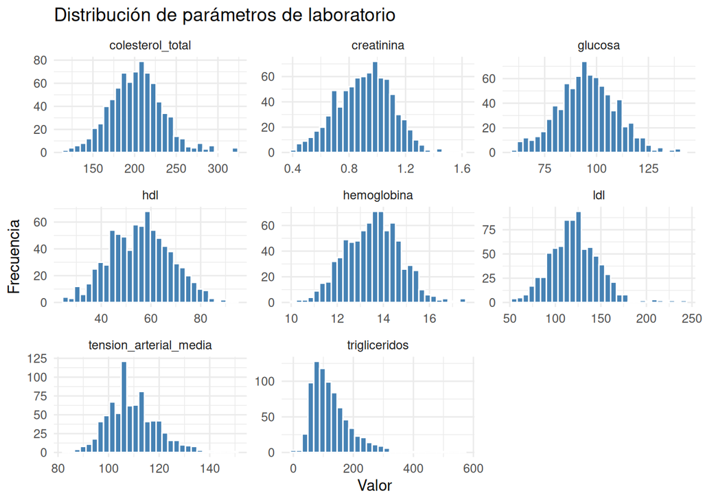

```r
# Un histograma para cada uno de los parámetros del laboratorio
vars_lab <- c("tension_arterial_media", "glucosa", "hdl", "ldl",
            "trigliceridos", "creatinina", "hemoglobina", "colesterol_total")

df_var %>%
  select(all_of(vars_lab)) %>%
  pivot_longer(cols = everything(), names_to = "biomarcador", values_to = "valor") %>%
  ggplot(aes(x = valor)) +
  geom_histogram(bins = 30, fill = "steelblue", color = "white") +
  facet_wrap(~biomarcador, scales = "free") +
  theme_minimal() +
  labs(title = "Distribución de parámetros de laboratorio", x = "Valor", y = "Frecuencia")
```

Observando la distribución de estos histogramas se puede apreciar que la mayoría de los parámetros tienen una distribución normal, incluyendo variables como la hemoglobina, creatinina, glucosa, HDL y colesterol total, lo que indica que la mayoría de las pacientes tienen valores dentro de los rangos esperados. Sin embargo, hay algunas variables como LDL, triglicéridos y tensión media que presentan una ligera asimetría positiva, lo que sugiere que hay un número significativo de pacientes con niveles elevados de estos parámetros, lo cual podría ser indicativo de un mayor riesgo cardiovascular en esta población.

### Cuestiones específicas

```r
# ¿Cuál es el porcentaje de cesáreas en la muestra?
df_var %>%
  count(cesarea) %>%
  mutate(porcentaje = n / sum(n) * 100)
```

```
# A tibble: 2 × 3
  cesarea     n porcentaje
  <fct>   <int>      <dbl>
1 No        630       79.0
2 Sí        167       21.0
```

```r
# ¿Cuál es la media de edad de las mujeres con cesárea y cuál es la media de edad de las
# mujeres sin cesárea?
df_var %>%
  group_by(cesarea) %>%
  summarise(
    media_edad = mean(edad_de_la_madre, na.rm = TRUE),
    n = n()
  )
```

```
# A tibble: 2 × 3
  cesarea media_edad     n
  <fct>        <dbl> <int>
1 No            30.2   630
2 Sí            31.3   167
```

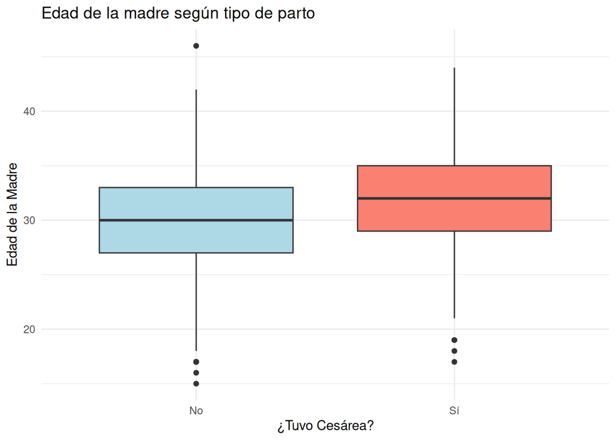

```r
# Un gráfico de cajas para la edad, separado por si la mujer tuvo o no cesárea.
df_var %>%
  ggplot(aes(x = cesarea, y = edad_de_la_madre, fill = cesarea)) +
  geom_boxplot() +
  theme_minimal() +
  labs(title = "Edad de la madre según tipo de parto",
       x = "¿Tuvo Cesárea?",
       y = "Edad de la Madre") +
  scale_fill_manual(values = c("No" = "lightblue", "Sí" = "salmon")) +
  theme(legend.position = "none")
```

```r
# De las mujeres que asistieron a clases de parto, ¿qué porcentaje tuvo cesárea?
df_var %>%
  filter(clases_de_parto == "Sí") %>%
  count(cesarea) %>%
  mutate(porcentaje = n / sum(n) * 100)
```

```
# A tibble: 2 × 3
  cesarea     n porcentaje
  <fct>   <int>      <dbl>
1 No        421       80.2
2 Sí        104       19.8
```

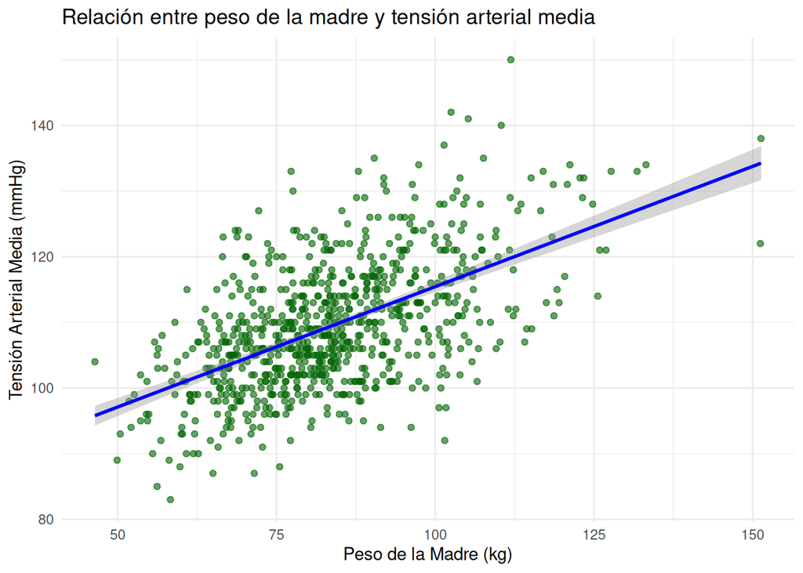

```r
# Un gráfico de dispersión que muestre la relación entre el peso de la madre y la tensión
# arterial y que incluya la línea de regresión.
df_var %>%
  ggplot(aes(x = peso_de_la_madre, y = tension_arterial_media)) +
  geom_point(alpha = 0.6, color = "darkgreen") +
  geom_smooth(method = "lm", color = "blue", se = TRUE) +
  theme_minimal() +
  labs(title = "Relación entre peso de la madre y tensión arterial media",
       x = "Peso de la Madre (kg)",
       y = "Tensión Arterial Media (mmHg)")
```

Observando el gráfico de dispersión, se puede observar una tendencia positiva entre el peso de la madre y la tensión arterial media, lo que indica que a medida que aumenta el peso de la madre, también tiende a aumentar su tensión arterial media, por lo cual se podría considerar el peso como un factor de riesgo para la hipertensión durante el embarazo. A pesar de esto, se aprecia una dispersión muy alta, lo que considero que indica que hay muchos otros factores que influyen en la tensión arterial que no están siendo considerados.